# seeds-classification-uci-ml

```python
import pandas as pd
import numpy as np
import scipy as sp
from sklearn.model_selection import train_test_split

#libraries for data visualization
import matplotlib.pyplot as plt
from matplotlib.colors import Normalize
import altair as alt
%matplotlib inline
import seaborn as sns
import copy

from sklearn.feature_selection import RFE, RFECV
from sklearn.model_selection import KFold, StratifiedKFold, GridSearchCV

from sklearn.cluster import AgglomerativeClustering, KMeans
from scipy.cluster.hierarchy import linkage, dendrogram, fcluster
from sklearn.neighbors import KNeighborsClassifier

from sklearn.metrics import accuracy_score, r2_score, mean_squared_error, mean_absolute_error, confusion_matrix
```

1. Introduction
2. Exploratory Data Analaysis
   1. Data Inspection
   2. Data Visualization & Cleaning
3. Model Selection & Analysis
4. Discussion & Conclusion
5. References

## 1. Introduction

GitHub link: https://github.com/machristensen1/student-perf-uci-ml/

In this project, we'll be taking a look at how various unsupervised models perform with respect to clustering seeds into different wheat species using data from the following dataset: https://archive.ics.uci.edu/dataset/236/seeds

We'll be taking a look at K-Means clustering and Agglomerative (Hierarchical) Clustering and how it compares against the supervised K Nearest Neighbors algorithm.

> The examined group comprised kernels belonging to three different varieties of wheat: Kama, Rosa and Canadian, 70 elements each, randomly selected forthe experiment. High quality visualization of the internal kernel structure was detected using a soft X-ray technique. It is non-destructive and considerably cheaper than other more sophisticated imaging techniques like scanning microscopy or laser technology. The images were recorded on 13x18 cm X-ray KODAK plates. Studies were conducted using combine harvested wheat grain originating from experimental fields, explored at the Institute of Agrophysics of the Polish Academy of Sciences in Lublin. The data set can be used for the tasks of classification and cluster analysis. To construct the data, seven geometric parameters of wheat kernels were measured:

The indepedent variables of interest are:

1. area A,
2. perimeter P,
3. compactness C = 4*pi*A/P^2,
4. length of kernel,
5. width of kernel,
6. asymmetry coefficient
7. length of kernel groove.

## 2. Exploratory Data Analysis

There are some formatting issues that will be corrected manually in our dataset. Some lines are not tabulated properly, which will be corrected manually given that there are only a few invalid lines. We'll also append header information to each of the columns.

```python
pd.read_csv("seeds_dataset.txt", sep = "\t", header = None, on_bad_lines = 'warn')
```

```
Skipping line 8: expected 8 fields, saw 10
Skipping line 36: expected 8 fields, saw 10
Skipping line 61: expected 8 fields, saw 9
Skipping line 69: expected 8 fields, saw 9
Skipping line 107: expected 8 fields, saw 9
Skipping line 136: expected 8 fields, saw 9
Skipping line 170: expected 8 fields, saw 9
Skipping line 171: expected 8 fields, saw 9
Skipping line 173: expected 8 fields, saw 9
Skipping line 202: expected 8 fields, saw 9
Skipping line 204: expected 8 fields, saw 9
```

|  | 0 | 1 | 2 | 3 | 4 | 5 | 6 | 7 |
| --- | --- | --- | --- | --- | --- | --- | --- | --- |
| 0 | 15.26 | 14.84 | 0.8710 | 5.763 | 3.312 | 2.221 | 5.220 | 1 |
| 1 | 14.88 | 14.57 | 0.8811 | 5.554 | 3.333 | 1.018 | 4.956 | 1 |
| 2 | 14.29 | 14.09 | 0.9050 | 5.291 | 3.337 | 2.699 | 4.825 | 1 |
| 3 | 13.84 | 13.94 | 0.8955 | 5.324 | 3.379 | 2.259 | 4.805 | 1 |
| 4 | 16.14 | 14.99 | 0.9034 | 5.658 | 3.562 | 1.355 | 5.175 | 1 |
| ... | ... | ... | ... | ... | ... | ... | ... | ... |
| 194 | 12.19 | 13.20 | 0.8783 | 5.137 | 2.981 | 3.631 | 4.870 | 3 |
| 195 | 11.23 | 12.88 | 0.8511 | 5.140 | 2.795 | 4.325 | 5.003 | 3 |
| 196 | 13.20 | 13.66 | 0.8883 | 5.236 | 3.232 | 8.315 | 5.056 | 3 |
| 197 | 11.84 | 13.21 | 0.8521 | 5.175 | 2.836 | 3.598 | 5.044 | 3 |
| 198 | 12.30 | 13.34 | 0.8684 | 5.243 | 2.974 | 5.637 | 5.063 | 3 |

199 rows × 8 columns

```python
import warnings
warnings.filterwarnings("ignore")

data = pd.read_csv("seeds_dataset_clean.txt", sep = "\t", header = None, on_bad_lines = 'warn')
data.columns = ['Area', 'Perimeter', "Compactness", "Length", "Width", "Asymmetry", "Groove_Length", "Seed_id"]
```

### 2.A. Data Inspection

```python
data.head()
```

[output not shown]

```python
data.isnull().sum()
```

```
Area             0
Perimeter        0
Compactness      0
Length           0
Width            0
Asymmetry        0
Groove_Length    0
Seed_id          0
dtype: int64
```

```python
data.describe()
```

|  | Area | Perimeter | Compactness | Length | Width | Asymmetry | Groove_Length | Seed_id |
| --- | --- | --- | --- | --- | --- | --- | --- | --- |
| count | 210.000000 | 210.000000 | 210.000000 | 210.000000 | 210.000000 | 210.000000 | 210.000000 | 210.000000 |
| mean | 14.847524 | 14.559286 | 0.870999 | 5.628533 | 3.258605 | 3.700201 | 5.408071 | 2.000000 |
| std | 2.909699 | 1.305959 | 0.023629 | 0.443063 | 0.377714 | 1.503557 | 0.491480 | 0.818448 |
| min | 10.590000 | 12.410000 | 0.808100 | 4.899000 | 2.630000 | 0.765100 | 4.519000 | 1.000000 |
| 25% | 12.270000 | 13.450000 | 0.856900 | 5.262250 | 2.944000 | 2.561500 | 5.045000 | 1.000000 |
| 50% | 14.355000 | 14.320000 | 0.873450 | 5.523500 | 3.237000 | 3.599000 | 5.223000 | 2.000000 |
| 75% | 17.305000 | 15.715000 | 0.887775 | 5.979750 | 3.561750 | 4.768750 | 5.877000 | 3.000000 |
| max | 21.180000 | 17.250000 | 0.918300 | 6.675000 | 4.033000 | 8.456000 | 6.550000 | 3.000000 |

### 2.B. Data Visualization & Cleaning

Let's take a look at histograms and plots of subsets of our data to see if we need to perform any additional cleaning.

```python
d = {1 : 'Kama', 2: 'Rosa', 3: 'Canadian'}
data['Seed'] = data['Seed_id'].map(d)

means = data.groupby("Seed").mean().reset_index()
means
```

|  | Seed | Area | Perimeter | Compactness | Length | Width | Asymmetry | Groove_Length | Seed_id |
| --- | --- | --- | --- | --- | --- | --- | --- | --- | --- |
| 0 | Canadian | 11.873857 | 13.247857 | 0.849409 | 5.229514 | 2.853771 | 4.788400 | 5.116400 | 3.0 |
| 1 | Kama | 14.334429 | 14.294286 | 0.880070 | 5.508057 | 3.244629 | 2.667403 | 5.087214 | 1.0 |
| 2 | Rosa | 18.334286 | 16.135714 | 0.883517 | 6.148029 | 3.677414 | 3.644800 | 6.020600 | 2.0 |

```python
cats = ["Area", "Perimeter", "Compactness", "Length", "Width", "Groove_Length"]

base = alt.Chart(means)
dropdown = alt.binding_select(options = cats,
                             name = "Select:")
selection = alt.selection_single(fields = ['column'],
                               value = [{'column': cats[0]}],
                               bind = dropdown)

bar = base.properties(width = 250, height = 250).transform_fold(
    cats,as_=['column', 'value']
).add_selection(
    selection
).transform_filter(
    selection
).mark_bar(size = 20).encode(
    y = alt.Y('value:Q').title("Mean"),
    x = "Seed"
)

bar
```

[interactive chart not shown]

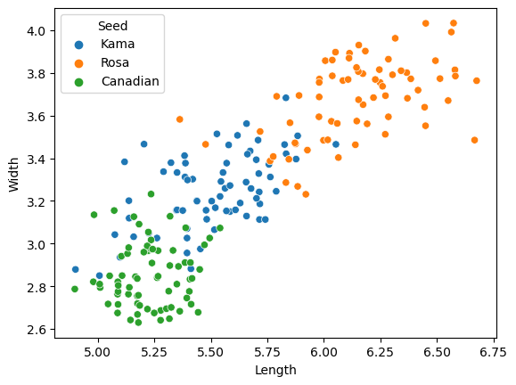

```python
sns.scatterplot(data, x = "Length", y = "Width", hue="Seed")
```

## Outliers

```python
def boxplot(column):
    sns.boxplot(data,x=data[f"{column}"], y = "Seed",)
    plt.title(f"Seed {column}")
    plt.show()
```

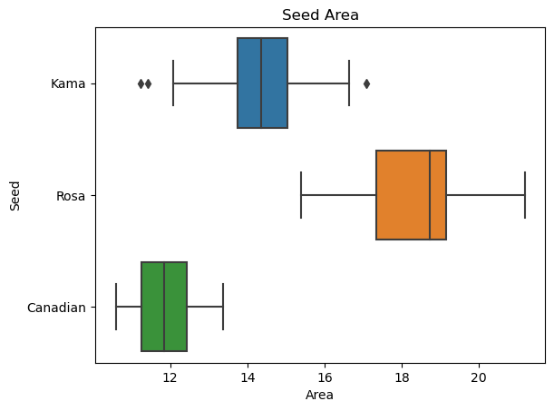

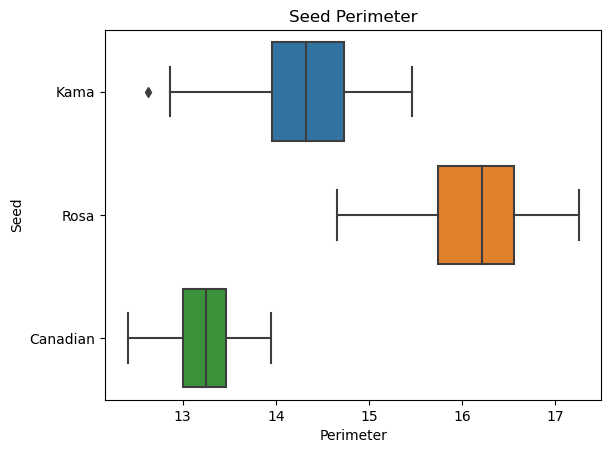

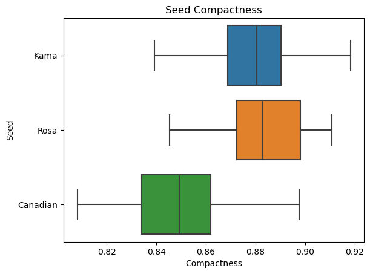

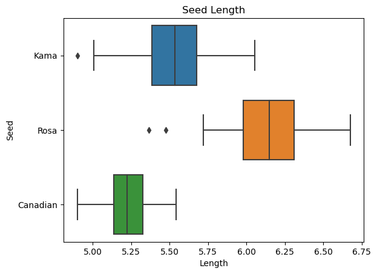

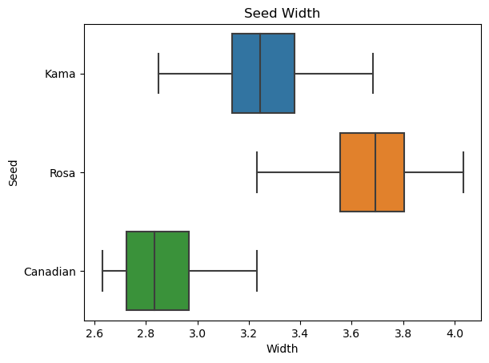

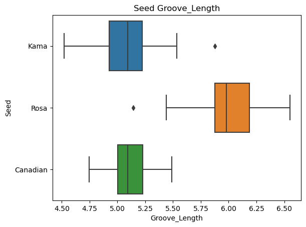

```python
for col in cats:
    boxplot(col)
```

## Collinearity/Correlation

Although many of the variables appear to be highly correlated, we are mainly concerned about maximizing our predictive power. The models we are using do not lose that much fidelity from correlated/collinear data. `Length` and `Width` are likely the most important factors in terms of model performance since the other factors are mathematically proportional to `Length` and `Width` (e.g. `Area`, `Perimeter`, `Compactness`).

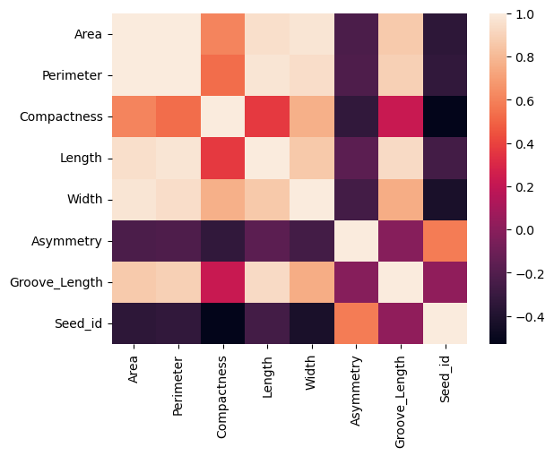

```python
sns.heatmap(data.corr(numeric_only = True))
```

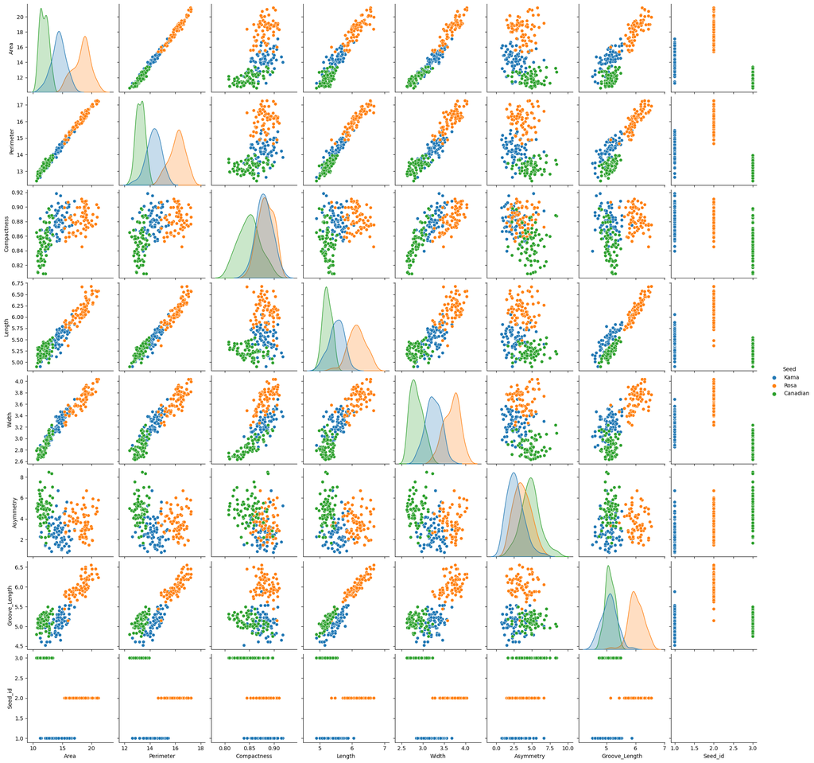

```python
sns.pairplot(data, diag_kind = 'kde', hue = "Seed")
```

From the pairplots above, it doesn't look like our data needs further transformation - the KDE plots look fairly normal and although we have an issue with collinearity, this should not impact our model.

# 3. Model Selection & Analysis

## K-Means Clustering

```python
data_unlabeled = data.drop(columns = ["Seed","Seed_id"], axis = 1)
```

```python
#Kmeans
km_model = KMeans(n_clusters = 3, n_init = 'auto', random_state = 0).fit(data_unlabeled)
km_labels = km_model.fit_predict(data_unlabeled)

data['km'] = km_labels
```

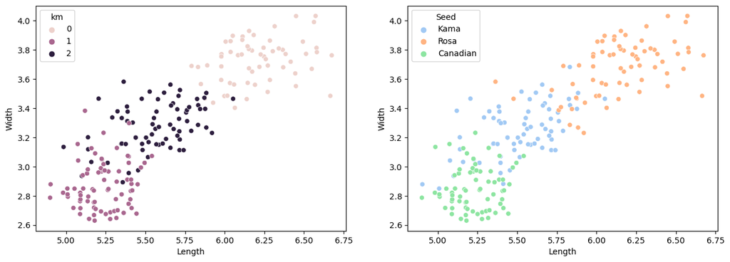

```python
fig, axs = plt.subplots(ncols=2, figsize = (15,5))


sns.scatterplot(data, x = "Length", y = "Width", hue="km", ax = axs[0])
sns.scatterplot(data, x = "Length", y = "Width", hue="Seed", palette = "pastel", ax = axs[1])
```

### Label Encoding & Accuracy Score

On inspection, we see that the labels are `0: Rosa`, `1: Canadian`, and `2: Kama`.

```python
d
```

```
{1: 'Kama', 2: 'Rosa', 3: 'Canadian'}
```

```python
d_km = {
    0: 2, #Rosa
    1: 3, #Canadian
    2: 1, #Kama
}

data['km'] = data['km'].map(d_km)
```

```python
km_acc = accuracy_score(data['Seed_id'], data['km'])
print("The accuracy of K-Means clustering is:", km_acc)
```

```
The accuracy of K-Means clustering is: 0.8952380952380953
```

```python
cm = confusion_matrix(data["Seed_id"],data['km'])
cm
```

```
array([[60,  1,  9],
       [10, 60,  0],
       [ 2,  0, 68]], dtype=int64)
```

## Hierarchical Clustering

```python
ac_model = AgglomerativeClustering(n_clusters = 3)
ac_labels = ac_model.fit_predict(data_unlabeled)

data_ac = data_unlabeled
data['ac'] = ac_labels
```

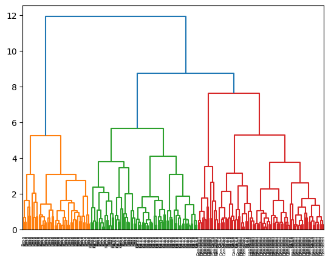

```python
mergings = linkage(data_unlabeled, method = "complete")

plt.figure()
dend = dendrogram(mergings,
          labels = data["Seed"].values)
```

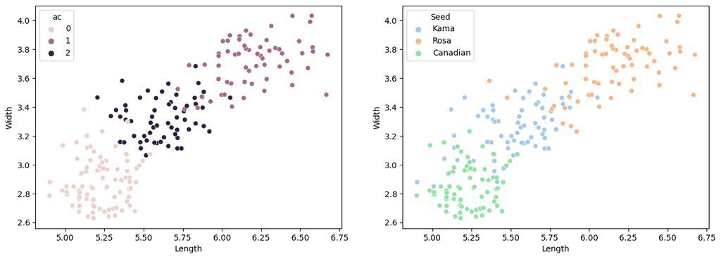

```python
fig, axs = plt.subplots(ncols=2, figsize = (15,5))


sns.scatterplot(data, x = "Length", y = "Width", hue="ac", ax = axs[0])
sns.scatterplot(data, x = "Length", y = "Width", hue="Seed", palette = "pastel", ax = axs[1])
```

```python
d
```

```
{1: 'Kama', 2: 'Rosa', 3: 'Canadian'}
```

```python
d_ac = {
    0: 3, #Canadian
    1: 2, #Rosa
    2: 1, #Kama
}

data['ac'] = data['ac'].map(d_ac)
```

```python
ac_acc = accuracy_score(data['Seed_id'], data['ac'])
print("The accuracy of agglomerative clustering is:", ac_acc)
```

```
The accuracy of agglomerative clustering is: 0.8904761904761904
```

```python
cm = confusion_matrix(data["Seed_id"],data['ac'])
cm
```

```
array([[54,  0, 16],
       [ 7, 63,  0],
       [ 0,  0, 70]], dtype=int64)
```

## K-Neighbors Clustering

```python
data.head()
data_sup = data.iloc[:,:8]

X = data_sup.iloc[:,:7]
y = data_sup.iloc[:,-1]

X_train, X_test, y_train, y_test = train_test_split(X,y, test_size = 0.25, random_state = 0)
```

```python
neigh = KNeighborsClassifier()


param_grid={'n_neighbors':np.arange(1,50)}

grid = GridSearchCV(neigh,
                    param_grid,
                    cv=10,
                    scoring='accuracy')

grid.fit(X_train, y_train)
grid.best_params_
```

```
{'n_neighbors': 1}
```

```python
y_pred_train = grid.predict(X_train)
y_pred = grid.predict(X_test)
```

```python
knn_acc_train = accuracy_score(y_train, y_pred_train)
knn_acc = accuracy_score(y_test, y_pred)
print("The train accuracy of KNN is:", knn_acc_train)
print("The test accuracy of KNN is:", knn_acc)
```

```
The train accuracy of KNN is: 1.0
The test accuracy of KNN is: 0.8867924528301887
```

```python
cm = confusion_matrix(y_test,y_pred)
cm
```

[output not shown]

```python
from tabulate import tabulate

scores = [
    ["KMeans", km_acc],
    ["Agg", ac_acc],
    ["KNN", knn_acc],

]

head = ["Model","Acc"]

print(tabulate(scores, headers = head))
```

```
Model         Acc
-------  --------
KMeans   0.895238
Agg      0.890476
KNN      0.886792
```

## Analysis

# Discussion & Conclusion

The parent paper utilized a different clustering algorithm called the Complete Gradient Clustering Algorithm and was able to achieve an accuracy of about `92%`. What is interesting about this algorithm is that it did not require the number of clusters to be identified as a hyperparameter before modeling, and still performed better than my application of KMeans clustering.

Classification success for original paper:

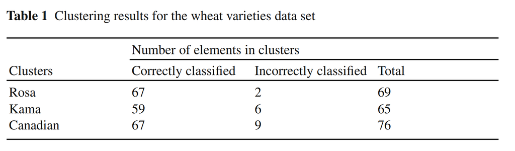

We could likely improve model performance by utilizing PCA/NMF to reduce the dimensionality of the dataset before applying our models.

Additionally, the CGCA algorithm was able to identify what they called "one-element clusters" which are essentially outliers in our data. While they didn't remove any outliers in the original paper, it is possible that we could have improved the performance of our models by removing outliers in the data.

# References

Charytanowicz,Magorzata, Niewczas,Jerzy, Kulczycki,Piotr, Kowalski,Piotr, and Lukasik,Szymon. (2012). Seeds. UCI Machine Learning Repository. https://doi.org/10.24432/C5H30K.